# Desarrollo de modelo de regresión lineal simple

Ejemplo de aplicación en Python y R

Autor/a

Afiliación

Víctor Gauto

[GISTAQ (UTN-FRRe)](https://www.instagram.com/gistaq.utn/)

Fecha de publicación

24 de abril de 2025

Resumen

Palabras clave

GISTAQ, UTN, FRRe, Quarto

Diferentes metodologías para la resolución de una regresión simple por el método de mínimos cuadrados.

## 1 **Python**, con `sklearn`

Se muestra a continuación el tutorial mostrado en para el modelo [Mínimos cuadrados ordinarios](https://scikit-learn.org/stable/auto_examples/linear_model/plot_ols.html#ordinary-least-squares-example).

Importo la librería `sklearn`, funciones de interés y para generar figuras.

```python
from sklearn.datasets import load_diabetes
from sklearn.model_selection import train_test_split
from sklearn.linear_model import LinearRegression
from sklearn.metrics import mean_squared_error, r2_score
import matplotlib.pyplot as plt
```

Cargo los datos de interés y divido en entrenamiento y validación.

```python
X, y = load_diabetes(return_X_y=True)
X = X[:, [2]]  # Use only one feature
X_train, X_test, y_train, y_test = train_test_split(
  X, y, test_size=20, shuffle=False
)
```

Creo un modelo de regresión y ajusto utilizando los datos de entrenamiento.

```python
regressor = LinearRegression().fit(X_train, y_train)
```

Evalúo el modelo generado a partir de las **métricas de desempeño**.

```python
y_pred = regressor.predict(X_test)
p_rmse = mean_squared_error(y_test, y_pred)
p_r2 = r2_score(y_test, y_pred)
```

**Métricas de desempeño**

El error cuadrático medio es: 2548.072.

El coeficiente de determinación (R<sup>2</sup>) es: 0.473.

Visualizo los resultados comparando el conjunto de entrenamiento y validación.

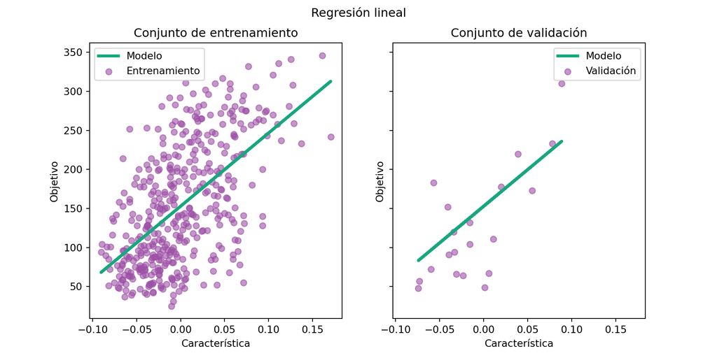

```python
fig, ax = plt.subplots(ncols=2, figsize=(10, 5), sharex=True, sharey=True)

ax[0].plot(
    X_train,
    regressor.predict(X_train),
    linewidth=3,
    color="#17A77E",
    label="Modelo",
)
ax[0].scatter(X_train, y_train, label="Entrenamiento", color = "#9D50A6", alpha = .6)
ax[0].set(xlabel="Característica", ylabel="Objetivo", title="Conjunto de entrenamiento")
ax[0].legend()

ax[1].plot(X_test, y_pred, linewidth=3, color="#17A77E", label="Modelo")
ax[1].scatter(X_test, y_test, label="Validación", color = "#9D50A6", alpha = .6)
ax[1].set(xlabel="Característica", ylabel="Objetivo", title="Conjunto de validación")
ax[1].legend()

fig.suptitle("Regresión lineal")

plt.show()
```

## 2 **R**, con `tidymodels`

Cargo los paquetes para el procesamiento de datos y desarrollo del modelo.

```r
library(tidyverse)
library(tidymodels)
```

Divido el conjunto de datos en entrenamiento y validación.

```r
penguins <- palmerpenguins::penguins

set.seed(2025)
penguins_split <- initial_split(penguins, strata = body_mass_g)
penguins_train <- training(penguins_split)
penguins_test  <- testing(penguins_split)
```

Creo un modelo lineal y una *receta* que relacione las variables de interés.

```r
lm_model <- linear_reg() |>
  set_engine("lm")

lm_recipe <- recipe(body_mass_g ~ bill_length_mm, data = penguins_train)
```

Combino el modelo con la receta en un *workflow* y ajusto con los datos de entrenamiento.

```r
lm_wflow <- workflow(
  preprocessor = lm_recipe,
  spec = lm_model
)

lm_fit <- fit(lm_wflow, penguins_train)
```

Genero estimaciones a partir de los datos de validación con el modelo obtenido.

```r
penguins_test_res <- predict(
  lm_fit, new_data = select(penguins_test, -body_mass_g)
) |>
  bind_cols(select(penguins_test, body_mass_g))
```

Las métricas de desempeño resultan:

```r
r_rmse <- yardstick::rmse(penguins_test_res, truth = body_mass_g, estimate = .pred)
r_r2 <- yardstick::rsq(penguins_test_res, truth = body_mass_g, estimate = .pred)
```

**Métricas de desempeño**

El error cuadrático medio (RMSE): 668.348.

El coeficiente de determinación (R<sup>2</sup>): 0.322.

Comparo las estimaciones dadas por el modelo con los valores reales.

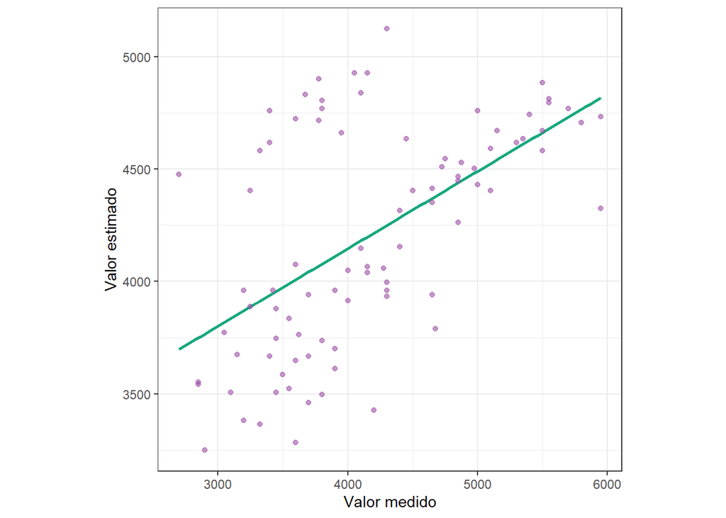

```r
ggplot(penguins_test_res, aes(body_mass_g, .pred)) +
  geom_smooth(se = FALSE, method = "lm", formula = y ~ x, color = "#17A77E") +
  geom_point(color = "#9D50A6", alpha = .6) +
  labs(x = "Valor medido", y = "Valor estimado") +
  theme_bw() +
  theme(
    aspect.ratio = 1
  )
```

Más recursos:

- [Tutoriales](https://www.tidymodels.org/start/) de `{tidymodels}`.
- [Tidy Modeling with R](https://www.tmwr.org/).